[interactive chart not shown]

Press `→` or click to advance

Full-stack AI products, built end to end

# AI products that actually ship.

Architecture and development for LLM-powered applications: eval-first pipelines, production APIs and polished front-ends, from first prototype to production.

ohmeow — zsh

$ ohmeow ship \  
--product "your-ai-product"

**Wayde Gilliam** · Founder, ohmeow · 25+ years shipping software

Open with the one-line promise: AI products that actually ship. Introduce yourself as the person who designs, builds and deploys the whole thing, then move straight to the client's problem.

The gap

## The demo works. Getting it to production is the hard part.

01 · Quality

### Quality is a feeling

Without evals, nobody can say whether the last change made the model better or worse.

02 · Engineering

### The prototype doesn't scale

A notebook and a chat box aren't a product. Auth, APIs, data, deployment and monitoring are.

03 · Ownership

### The work is split up

ML, backend, frontend and DevOps hand off to each other, and the product stalls in between.

Name the pain the client already feels. Most teams can get a convincing demo. The hard part is everything between that demo and a product people rely on: measuring quality, real engineering, and one owner across the stack.

The approach

## One engineer. The whole stack.

ohmeow designs, builds and deploys LLM-powered products end to end, so nothing gets lost between handoffs and every layer is built to work with the one next to it.

● One owner, interface to infrastructure

### Interface

what users touch

VueQuasarReactNext.js

### API

production services

FastAPINode.js

### Intelligence

the AI core

LLMsRAGAgentsGuardrailsEvals

### Platform

data & delivery

PostgreSQLDockerCloudCI/CD

This is the core differentiator. Instead of coordinating a data scientist, two developers and a DevOps contractor, the client gets one accountable person who designs every layer to fit together. The stack builds from the platform up.

Services

## Three ways I can help.

Build the AI product, build the application around it, or help your team choose and learn. Most engagements start with one and grow into another.

### AI & ML application development

- LLM apps, RAG and agents
- NLP workflows
- Forecasting and classification models
- Eval-first pipelines

### Full-stack engineering

- Vue, Quasar, React and Next.js front-ends
- FastAPI, ASP.NET Core and Node.js back-ends
- PostgreSQL, Docker and cloud deployments

### AI strategy & enablement

- Technical evaluations and benchmarking
- AI-driven product architecture
- Team training and workshops

Most clients come in through one door: build the AI product, build the full-stack app around it, or help the team decide and learn. Ask which one fits their situation today.

How we work

## Weeks, not quarters.

01

### Discover

We scope the problem, the users, and what “good” looks like, then agree on a plan measured in weeks, not quarters.

02

### Prototype

A working slice of the product, fast. Real data, real users, real feedback before big investments are made.

03

### Evaluate

Evals and error analysis drive every iteration, so quality is something we can see and improve.

04

### Ship & support

Deployed, monitored, documented and handed off cleanly, with ongoing support when you want it.

ohmeow — engagement.log

Walk the four steps. Stress that the plan is measured in weeks and that the client sees a working slice early, on real data, before committing a big budget.

Eval-first AI

## Quality you can see.

Evals and error analysis drive every iteration, so quality is something we can see and improve, not just feel.

✓

**Measure before prompting.** Success is defined and measured before the first prompt is written.

✓

**Fix what the data shows.** Error analysis on real traces decides what to work on next.

✓

**Done this for the tools themselves.** Redesigned the evals and observability experience for PydanticAI and Logfire.

This is the part most AI vendors skip. Explain the loop: trace real usage, review it, group failures into categories, fix the biggest one, re-run the evals. Mention the PydanticAI and Logfire work as proof this is a specialty.

Clients & employers

## From startups to enterprise.

Education · Safety

### Safer Schools Together

Architect and lead developer of DTAM, an AI-powered threat assessment platform for schools.

Evals · Observability

### PydanticAI / Logfire

Redesigned the evals and observability experience.

LLM tooling

### Answer.AI

Contributed to core libraries and tutorials for LLM tooling.

ML education

### Weights & Biases

Educational content on fast.ai and blurr with Hugging Face transformers.

Agriculture

### Agrilynk

A production AI platform for real-time agricultural insights.

Higher education

### UC San Diego

Survey and analytics platform, a qualitative-data AI pipeline and HR forecasting models.

Pick the one or two tiles closest to the client's industry and tell that story. Safer Schools Together and PydanticAI are the strongest AI examples.

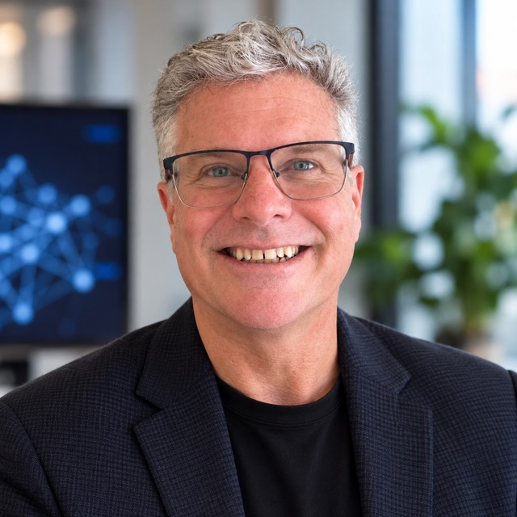

Founder · ohmeow.com

Who you're hiring

## Wayde Gilliam

Founder of ohmeow and a full-stack and AI/ML engineer. Author of **blurr**, the library for training Hugging Face transformers with fast.ai, and a fast.ai community leader.

25+

years shipping

10+

companies served

1

owner, end to end

PythonPyTorchfast.aiHugging FaceLLMs & evalsFastAPIVue / QuasarReact / Next.jsPostgreSQLDocker

Keep it human. Twenty-five years of shipping, open-source work the AI community uses, and the person they talk to is the person who writes the code. Outside work: two labradors, reading, working out, always learning.

Next step

# Let's ship your AI product.

Start with a discovery call. We'll scope the problem, define what good looks like and agree on a plan.

wgilliam@ohmeow.com [ohmeow.com ↗](https://ohmeow.com)

github.com/ohmeow [linkedin.com/in/wgilliam](https://www.linkedin.com/in/wgilliam/) x.com/waydegilliam

ohmeow — zsh

$ ohmeow ship --product  
"your-ai-product"  
✔ shipped measured, monitored,  
improving  
$

Close with a concrete, low-risk next step: a discovery call. Leave this slide up during questions.

Turn your phone sideways for the full deck